# Prediction of VaR and Dynamic Portfolio Risk Hedging

```python
print("Missing Values : \n",data.isnull().sum())
```

```
Missing Values :
 Unnamed: 0             0
Date                 752
Natural_Gas_Price      0
Natural_Gas_Vol.       4
Crude_oil_Price        0
Crude_oil_Vol.        23
Copper_Price           0
Copper_Vol.           37
Bitcoin_Price          0
Bitcoin_Vol.           0
Platinum_Price         0
Platinum_Vol.        607
Ethereum_Price         0
Ethereum_Vol.          0
S&P_500_Price          0
Nasdaq_100_Price       0
Nasdaq_100_Vol.        1
Apple_Price            0
Apple_Vol.             0
Tesla_Price            0
Tesla_Vol.             0
Microsoft_Price        0
Microsoft_Vol.         0
Silver_Price           0
Silver_Vol.           47
Google_Price           0
Google_Vol.            0
Nvidia_Price           0
Nvidia_Vol.            0
Berkshire_Price        0
Berkshire_Vol.         0
Netflix_Price          0
Netflix_Vol.           0
Amazon_Price           0
Amazon_Vol.            0
Meta_Price             0
Meta_Vol.              0
Gold_Price             0
Gold_Vol.              2
day_of_year          752
year                 752
dtype: int64
```

```python
# Drop columns from the dataset
data.drop(['Platinum_Price', 'Platinum_Vol.'], axis=1, inplace=True)

print(data.isnull().sum())
```

```
Unnamed: 0             0
Date                 752
Natural_Gas_Price      0
Natural_Gas_Vol.       4
Crude_oil_Price        0
Crude_oil_Vol.        23
Copper_Price           0
Copper_Vol.           37
Bitcoin_Price          0
Bitcoin_Vol.           0
Ethereum_Price         0
Ethereum_Vol.          0
S&P_500_Price          0
Nasdaq_100_Price       0
Nasdaq_100_Vol.        1
Apple_Price            0
Apple_Vol.             0
Tesla_Price            0
Tesla_Vol.             0
Microsoft_Price        0
Microsoft_Vol.         0
Silver_Price           0
Silver_Vol.           47
Google_Price           0
Google_Vol.            0
Nvidia_Price           0
Nvidia_Vol.            0
Berkshire_Price        0
Berkshire_Vol.         0
Netflix_Price          0
Netflix_Vol.           0
Amazon_Price           0
Amazon_Vol.            0
Meta_Price             0
Meta_Vol.              0
Gold_Price             0
Gold_Vol.              2
day_of_year          752
year                 752
dtype: int64
```

```python
# Completeness: Checking for missing values
missing_data = data.isnull().sum()
print("Completeness (Missing Values):\n", missing_data[missing_data > 0])
```

```
Completeness (Missing Values):
 Date                752
Natural_Gas_Vol.      4
Crude_oil_Vol.       23
Copper_Vol.          37
Nasdaq_100_Vol.       1
Silver_Vol.          47
Gold_Vol.             2
day_of_year         752
year                752
dtype: int64
```

```python
import numpy as np
# Measures for Data Quality
# Accuracy: Checking for unusual or erroneous values (e.g., negative prices)
accuracy_issues = data[(data.select_dtypes(include=[np.number]) < 0).any(axis=1)]
print("Accuracy Issues (Negative Values):\n", accuracy_issues)
```

```
Accuracy Issues (Negative Values):
      Unnamed: 0 Date  Natural_Gas_Price  Natural_Gas_Vol.  Crude_oil_Price  \
938         938  NaT              1.924          229820.0           -37.63

     Crude_oil_Vol.  Copper_Price  Copper_Vol.  Bitcoin_Price  Bitcoin_Vol.  \
938        247950.0         2.328       1260.0         6833.5     1260000.0

     ...  Netflix_Price  Netflix_Vol.  Amazon_Price  Amazon_Vol.  Meta_Price  \
938  ...         437.49    12660000.0        119.68  115410000.0      178.24

      Meta_Vol.  Gold_Price  Gold_Vol.  day_of_year  year
938  16110000.0      1711.2   186910.0          NaN   NaN

[1 rows x 39 columns]
```

```python
# Consistency: Checking for duplicates and inconsistent data
duplicates = data.duplicated().sum()
print(f"Number of Duplicate Rows: {duplicates}")
```

```
Number of Duplicate Rows: 0
```

```python
#Allows replacing the current value with the previous day's value
data.fillna(method='bfill', inplace=True)
print(data.isnull().sum())
```

```
Unnamed: 0           0
Date                 0
Natural_Gas_Price    0
Natural_Gas_Vol.     0
Crude_oil_Price      0
Crude_oil_Vol.       0
Copper_Price         0
Copper_Vol.          0
Bitcoin_Price        0
Bitcoin_Vol.         0
Ethereum_Price       0
Ethereum_Vol.        0
S&P_500_Price        0
Nasdaq_100_Price     0
Nasdaq_100_Vol.      0
Apple_Price          0
Apple_Vol.           0
Tesla_Price          0
Tesla_Vol.           0
Microsoft_Price      0
Microsoft_Vol.       0
Silver_Price         0
Silver_Vol.          0
Google_Price         0
Google_Vol.          0
Nvidia_Price         0
Nvidia_Vol.          0
Berkshire_Price      0
Berkshire_Vol.       0
Netflix_Price        0
Netflix_Vol.         0
Amazon_Price         0
Amazon_Vol.          0
Meta_Price           0
Meta_Vol.            0
Gold_Price           0
Gold_Vol.            0
day_of_year          0
year                 0
dtype: int64
```

Finally, the code calculates daily logarithmic returns for the S&P 500 indices to analyze their performance and volatility over time:

```python
#Calculation of Logarithmic Returns for S&P 500

data['S&P_500_Log_Returns'] = np.log(data['S&P_500_Price'] / data['S&P_500_Price'].shift(1))
```

```python
data.head()
```

|  | Unnamed: 0 | Date | Natural_Gas_Price | Natural_Gas_Vol. | Crude_oil_Price | Crude_oil_Vol. | Copper_Price | Copper_Vol. | Bitcoin_Price | Bitcoin_Vol. | ... | Netflix_Vol. | Amazon_Price | Amazon_Vol. | Meta_Price | Meta_Vol. | Gold_Price | Gold_Vol. | day_of_year | year | S&P_500_Log_Returns |
| --- | --- | --- | --- | --- | --- | --- | --- | --- | --- | --- | --- | --- | --- | --- | --- | --- | --- | --- | --- | --- | --- |
| 0 | 0 | 2024-02-02 | 2.079 | 161340.0 | 72.28 | 577940.0 | 3.8215 | 38000.0 | 43194.7 | 42650.0 | ... | 4030000.0 | 171.81 | 117220000.0 | 474.99 | 84710000.0 | 2053.7 | 260920.0 | 33.0 | 2024.0 | NaN |
| 1 | 1 | 2024-01-02 | 2.050 | 161340.0 | 73.82 | 577940.0 | 3.8535 | 38000.0 | 43081.4 | 47690.0 | ... | 3150000.0 | 159.28 | 66360000.0 | 394.78 | 25140000.0 | 2071.1 | 260920.0 | 2.0 | 2024.0 | -0.010628 |
| 2 | 2 | 2024-12-01 | 2.100 | 142860.0 | 75.85 | 344490.0 | 3.9060 | 38000.0 | 42580.5 | 56480.0 | ... | 4830000.0 | 155.20 | 49690000.0 | 390.14 | 20010000.0 | 2067.4 | 238370.0 | 336.0 | 2024.0 | -0.011752 |
| 3 | 3 | 2024-12-01 | 2.077 | 139750.0 | 77.82 | 347240.0 | 3.9110 | 38000.0 | 42946.2 | 55130.0 | ... | 6120000.0 | 159.00 | 42290000.0 | 400.06 | 18610000.0 | 2050.9 | 214590.0 | 336.0 | 2024.0 | 0.015572 |
| 4 | 4 | 2024-12-01 | 2.490 | 3590.0 | 76.78 | 331930.0 | 3.8790 | 38000.0 | 43299.8 | 45230.0 | ... | 6880000.0 | 161.26 | 42840000.0 | 401.02 | 17790000.0 | 2034.9 | 1780.0 | 336.0 | 2024.0 | 0.000601 |

5 rows × 40 columns

Historical Method:

```python
# Initialize a list to store VaR values with the first 29 elements as 0
VaR_actual = [0] * 29

# Calculate the 5th percentile VaR over a rolling 30-day window
for i in range(len(data['S&P_500_Log_Returns']) - 29):
    x = data['S&P_500_Log_Returns'][i : i + 30].quantile(q=0.05, interpolation='nearest')
    VaR_actual.append(x)
```

Monte Carlo Method:

```python
# Monte Carlo simulation parameters
num_simulations = 10000
VaR_monte_carlo = [0] * 29
confidence_level = 0.05

# Calculate Monte Carlo VaR over a rolling 30-day window
for i in range(len(data['S&P_500_Log_Returns']) - 29):
    window_data = data['S&P_500_Log_Returns'][i : i + 30]
    mean_return = np.mean(window_data)
    std_dev = np.std(window_data)

    # Simulate returns
    simulated_returns = np.random.normal(mean_return, std_dev, num_simulations)

    # Calculate VaR from simulations at the specified confidence level
    var_value = -np.quantile(simulated_returns, 1 - confidence_level)
    VaR_monte_carlo.append(var_value)
```

```python
len(VaR_actual), len(data) , len(VaR_monte_carlo)
```

```
(1243, 1243, 1243)
```

```python
# Join the observed VaR vector to the log return dataframe
pd.options.mode.chained_assignment = None  # default='warn'
data['VaR_S&P_500'] = VaR_actual
data['VaR_S&P_500_montecarlo'] = VaR_monte_carlo
```

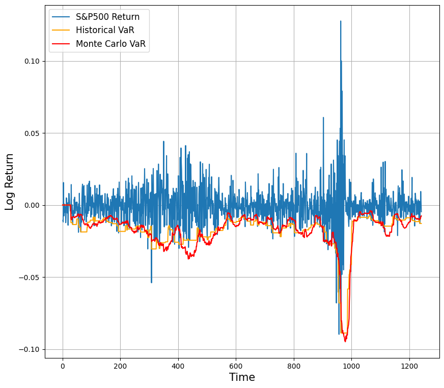

```python
# Plot log returns and VaR

plt.figure(figsize=(10, 9))
plt.plot(data.index, data['S&P_500_Log_Returns'], label='S&P500 Return', linewidth=1.5, linestyle='-')
#plt.plot(data.index, data['VaR_actual_new'], label="Actual VaR", linewidth=1.5, linestyle='-')
plt.plot(data.index, data['VaR_S&P_500'], label="Historical VaR", linewidth=1.5, linestyle='-', color='orange')
plt.plot(data.index, data['VaR_S&P_500_montecarlo'], label="Monte Carlo VaR", linewidth=1.5, linestyle='-', color='red')
plt.grid(True)
plt.ylabel('Log Return', color='black', size=15)
plt.xlabel('Time', color='black', size=15)
plt.legend(loc='upper left', fontsize=12)
plt.show()
```

```python
# verification of values
print(data[['Date', 'S&P_500_Log_Returns',  'VaR_S&P_500', 'VaR_S&P_500_montecarlo']].head(100))
```

```
         Date  S&P_500_Log_Returns  VaR_S&P_500  VaR_S&P_500_montecarlo
0  2024-02-02                  NaN     0.000000                0.000000
1  2024-01-02            -0.010628     0.000000                0.000000
2  2024-12-01            -0.011752     0.000000                0.000000
3  2024-12-01             0.015572     0.000000                0.000000
4  2024-12-01             0.000601     0.000000                0.000000
..        ...                  ...          ...                     ...
95 2023-12-09             0.002153    -0.011746               -0.015993
96 2023-12-09            -0.000721    -0.010539               -0.015849
97 2023-12-09             0.012234    -0.010539               -0.016239
98 2023-12-09            -0.008395    -0.010539               -0.015858
99 2023-12-09            -0.001241    -0.010539               -0.014869

[100 rows x 4 columns]
```

```python
# Remove rows where VaR = 0 (missing)
df = data[(data['VaR_S&P_500'] != 0)]
```

```python
data.head(5)
data.shape
```

```
(1243, 42)
```

## Prédiction de la VaR avec machine learning

```python
# Prepare data for VaR prediction using machine learning
# Feature columns include prices and volumes for various stocks, and the target column is historical VaR
features = data[[
    'Apple_Price', 'Apple_Vol.',
    'Tesla_Price', 'Tesla_Vol.',
    'Microsoft_Price', 'Microsoft_Vol.',
    'Google_Price', 'Google_Vol.',
    'Amazon_Price', 'Amazon_Vol.'
]]

# Target column for prediction (adjust as needed)
target = data['VaR_S&P_500']
```

```python
from sklearn.model_selection import train_test_split

# Split the data into training and testing sets
X_train, X_test, y_train, y_test = train_test_split(
    features, target, test_size=0.2, random_state=42
)
```

```python
from sklearn.linear_model import LinearRegression
from sklearn.model_selection import cross_val_score
from sklearn.metrics import mean_squared_error, mean_absolute_error, r2_score

# Initialize the linear regression model
linear_model = LinearRegression()

# Perform 5-fold cross-validation to compute R2 scores on the training set
scores = cross_val_score(linear_model, X_train, y_train, scoring='r2', cv=5)

# Train the model on the training data
linear_model.fit(X_train, y_train)

# Predict target values for the test data
y_pred = linear_model.predict(X_test)

# Print the model's performance metrics
print("Linear Regression")
print("Cross-validated R2 score:", scores.mean())  # Average R2 from cross-validation
print("Test RMSE:", np.sqrt(mean_squared_error(y_test, y_pred)))  # Root Mean Squared Error
print("Test MAE:", mean_absolute_error(y_test, y_pred))  # Mean Absolute Error
print("Test R2:", r2_score(y_test, y_pred))  # R2 score on test data
```

```
Linear Regression
Cross-validated R2 score: 0.3839836182448172
Test RMSE: 0.010876294370976494
Test MAE: 0.006249778077295924
Test R2: 0.3262865138565483
```

```python
# Importing GradientBoostingRegressor
from sklearn.ensemble import GradientBoostingRegressor

# Initialize the Gradient Boosting Regressor with specified parameters
gb_model = GradientBoostingRegressor(n_estimators=100, max_depth=3, learning_rate=0.1, random_state=42)

# Perform cross-validation to calculate the R2 score on the training set
scores = cross_val_score(gb_model, X_train, y_train, scoring='r2', cv=5)

# Train the Gradient Boosting model on the training data
gb_model.fit(X_train, y_train)

# Predict target values for the test data
y_pred = gb_model.predict(X_test)

# Print model performance metrics
print("Gradient Boosting Regressor")
print("Cross-validated R2 score:", scores.mean())  # Average R2 score from cross-validation
print("Test RMSE:", np.sqrt(mean_squared_error(y_test, y_pred)))  # Root Mean Squared Error on test data
print("Test MAE:", mean_absolute_error(y_test, y_pred))  # Mean Absolute Error on test data
print("Test R2:", r2_score(y_test, y_pred))  # R2 score on test data
```

```
Gradient Boosting Regressor
Cross-validated R2 score: 0.802007302455506
Test RMSE: 0.004789253325721558
Test MAE: 0.0028200608157100556
Test R2: 0.8693681873622937
```

```python
from sklearn.tree import DecisionTreeRegressor

# Initialize the Decision Tree Regressor with specified parameters
dt_model = DecisionTreeRegressor(max_depth=4, min_samples_leaf=5, random_state=42)

# Perform 5-fold cross-validation to compute R2 scores on the training set
scores = cross_val_score(dt_model, X_train, y_train, scoring='r2', cv=5)

# Train the model on the training data
dt_model.fit(X_train, y_train)

# Predict target values for the test data
y_pred = dt_model.predict(X_test)

# Print the model's performance metrics
print("Decision Tree Regressor")
print("Cross-validated R2 score:", scores.mean())  # Average R2 from cross-validation
print("Test RMSE:", np.sqrt(mean_squared_error(y_test, y_pred)))  # Root Mean Squared Error
print("Test MAE:", mean_absolute_error(y_test, y_pred))  # Mean Absolute Error
print("Test R2:", r2_score(y_test, y_pred))  # R2 score on test data
```

```
Decision Tree Regressor
Cross-validated R2 score: 0.4130196706061292
Test RMSE: 0.00809274774247013
Test MAE: 0.005031013691091669
Test R2: 0.6270029983491698
```

```python
from xgboost import XGBRegressor
from sklearn.metrics import mean_squared_error, r2_score

# Model parameters
n_estimators = 1000
early_stopping_rounds = 10  # Stop after 10 rounds with no improvement
best_score = float('inf')   # Initial high score for comparison
no_improvement_count = 0    # Counter for no improvement rounds

# Initialize the XGBoost Regressor
xgb_model = XGBRegressor(
    objective='reg:squarederror',
    max_depth=3,
    learning_rate=0.1,
    reg_alpha=0.1,
    reg_lambda=0.1,
    random_state=42
)

# Track validation scores
validation_scores = []

# Training with manual early stopping
for i in range(1, n_estimators + 1):
    # Set the current number of estimators
    xgb_model.set_params(n_estimators=i)
    xgb_model.fit(X_train, y_train)

    # Validate the model on the test set
    y_val_pred = xgb_model.predict(X_test)
    val_score = mean_squared_error(y_test, y_val_pred)

    # Record validation score
    validation_scores.append(val_score)

    # Check for improvement
    if val_score < best_score:
        best_score = val_score
        no_improvement_count = 0  # Reset counter
    else:
        no_improvement_count += 1

    # Stop if no improvement for the specified number of rounds
    if no_improvement_count >= early_stopping_rounds:
        print(f"Early stopping at iteration {i}")
        break

# Final evaluation after early stopping
y_pred = xgb_model.predict(X_test)
print("Test RMSE:", np.sqrt(mean_squared_error(y_test, y_pred)))
print("Test R2:", r2_score(y_test, y_pred))
```

```
Early stopping at iteration 85
Test RMSE: 0.006340888015262172
Test R2: 0.7710115904283148
```

```python
from sklearn.linear_model import Ridge
from sklearn.metrics import mean_squared_error, mean_absolute_error, r2_score
import numpy as np

# Initialize and train the Ridge regression model
ridge_model = Ridge(alpha=1.0)
ridge_model.fit(X_train, y_train)

# Make predictions on the test set
y_pred_ridge = ridge_model.predict(X_test)

# Compute evaluation metrics
rmse_ridge = np.sqrt(mean_squared_error(y_test, y_pred_ridge))
mae_ridge = mean_absolute_error(y_test, y_pred_ridge)
r2_ridge = r2_score(y_test, y_pred_ridge)

# Print metrics
print("Test RMSE:", rmse_ridge)  # Root Mean Squared Error
print("Test MAE:", mae_ridge)    # Mean Absolute Error
print("Test R2:", r2_ridge)      # R2 Score
```

```
Test RMSE: 0.010876293519483448
Test MAE: 0.006249775785223238
Test R2: 0.32628661934511016
```

```python
from sklearn.svm import SVR
from sklearn.model_selection import cross_val_score
from sklearn.metrics import mean_squared_error, mean_absolute_error, r2_score
import numpy as np

def svm_prediction(X_train, X_test, y_train, y_test):
    # Initialize the SVR model with an RBF kernel
    model = SVR(kernel='rbf')  # RBF kernel is used, but 'linear' or others can also be selected

    # Perform cross-validation to calculate the mean R² score
    scores = cross_val_score(model, X_train, y_train, cv=5, scoring='r2')

    # Train the model on the training dataset
    model.fit(X_train, y_train)

    # Predict the target variable for the test dataset
    y_pred = model.predict(X_test)

    # Compute and print evaluation metrics
    print("Support Vector Regression")
    print("Cross-validated R2 score:", scores.mean())  # Mean R2 score from cross-validation
    print("Test RMSE:", np.sqrt(mean_squared_error(y_test, y_pred)))  # Root Mean Squared Error
    print("Test MAE:", mean_absolute_error(y_test, y_pred))  # Mean Absolute Error
    print("Test R2:", r2_score(y_test, y_pred))  # R2 Score on test data

# Call the function with the training and test datasets
svm_prediction(X_train, X_test, y_train, y_test)
```

```
Support Vector Regression
Cross-validated R2 score: -4.705958697092546
Test RMSE: 0.029008629535235347
Test MAE: 0.02813944901564272
Test R2: -3.792562195809099
```

```
               Model  Cross-validated R2  Test RMSE  Test MAE   Test R2
0  Linear Regression            0.383984   0.010876  0.006250  0.326287
1  Gradient Boosting            0.802007   0.004789  0.002820  0.869368
2      Decision Tree            0.413020   0.008093  0.005031  0.627003
3            XGBoost            0.750659   0.006341  0.003400  0.771012
4              Ridge            0.383984   0.010876  0.006250  0.326287
```

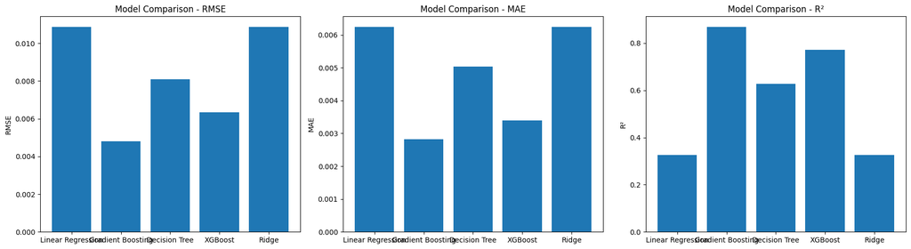

```python
# Initialize the models
models = {
    "Linear Regression": LinearRegression(),
    "Gradient Boosting": GradientBoostingRegressor(n_estimators=100, max_depth=3, learning_rate=0.1, random_state=42),
    "Decision Tree": DecisionTreeRegressor(max_depth=4, min_samples_leaf=5, random_state=42),
    "XGBoost": XGBRegressor(objective='reg:squarederror', n_estimators=100, max_depth=3, learning_rate=0.1, reg_alpha=0.1, reg_lambda=0.1, random_state=42),
    "Ridge": Ridge(alpha=1.0),
}

# Create a list to store results
results = []

# Loop through each model to compute metrics
for model_name, model in models.items():
    # Cross-validated R2
    scores = cross_val_score(model, X_train, y_train, scoring='r2', cv=5)
    cv_r2 = scores.mean()

    # Train and predict
    model.fit(X_train, y_train)
    y_pred = model.predict(X_test)

    # Calculate metrics
    rmse = np.sqrt(mean_squared_error(y_test, y_pred))
    mae = mean_absolute_error(y_test, y_pred)
    r2 = r2_score(y_test, y_pred)

    # Add results to the list
    results.append({
        "Model": model_name,
        "Cross-validated R2": cv_r2,
        "Test RMSE": rmse,
        "Test MAE": mae,
        "Test R2": r2
    })

# Convert results to a DataFrame for better visualization
results_df = pd.DataFrame(results)

# Display results
print(results_df)

# Visualization: Comparing the models
fig, axes = plt.subplots(1, 3, figsize=(18, 5))

# RMSE Chart
axes[0].bar(results_df["Model"], results_df["Test RMSE"])
axes[0].set_title("Model Comparison - RMSE")
axes[0].set_ylabel("RMSE")

# MAE Chart
axes[1].bar(results_df["Model"], results_df["Test MAE"])
axes[1].set_title("Model Comparison - MAE")
axes[1].set_ylabel("MAE")

# R² Chart
axes[2].bar(results_df["Model"], results_df["Test R2"])
axes[2].set_title("Model Comparison - R²")
axes[2].set_ylabel("R²")

plt.tight_layout()
plt.show()
```

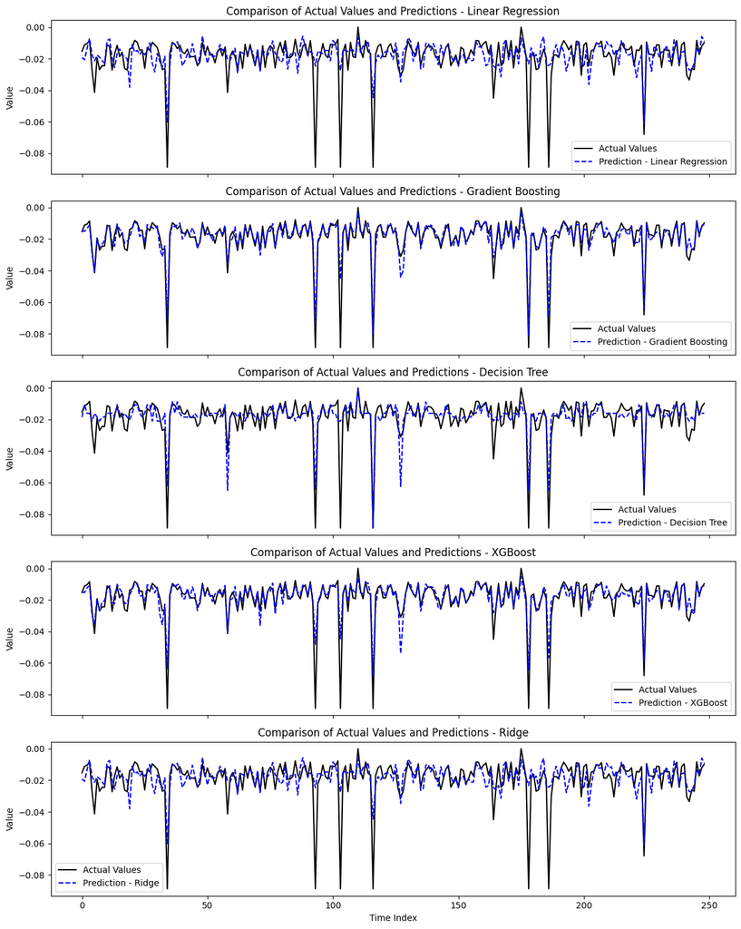

```python
import matplotlib.pyplot as plt

# Initialization of models
models = {
    "Linear Regression": LinearRegression(),
    "Gradient Boosting": GradientBoostingRegressor(n_estimators=100, max_depth=3, learning_rate=0.1, random_state=42),
    "Decision Tree": DecisionTreeRegressor(max_depth=4, min_samples_leaf=5, random_state=42),
    "XGBoost": XGBRegressor(objective='reg:squarederror', n_estimators=100, max_depth=3, learning_rate=0.1, reg_alpha=0.1, reg_lambda=0.1, random_state=42),
    "Ridge": Ridge(alpha=1.0),
}

# Training and storing predictions for each model
predictions = {}
for model_name, model in models.items():
    model.fit(X_train, y_train)  # Train the model
    y_pred = model.predict(X_test)  # Predict test data
    predictions[model_name] = y_pred  # Store predictions

# Create subplots for visualizing each model's predictions against actual values
fig, axes = plt.subplots(len(models), 1, figsize=(12, 3 * len(models)), sharex=True)

for i, (model_name, y_pred) in enumerate(predictions.items()):
    # Plot actual values
    axes[i].plot(y_test.reset_index(drop=True), label="Actual Values", color='black', linewidth=1.5)
    # Plot predicted values for the current model
    axes[i].plot(y_pred, label=f"Prediction - {model_name}", linestyle='--', color='blue')
    axes[i].set_title(f"Comparison of Actual Values and Predictions - {model_name}")
    axes[i].set_ylabel("Value")
    axes[i].legend()

# Configure x-axis label for the last subplot and adjust layout
axes[-1].set_xlabel("Time Index")
plt.tight_layout()
plt.show()
```

# Stage 2 : Advanced Techniques for Accurate and Reliable VaR Predictions

```python
# Core libraries
import numpy as np
import pandas as pd
import matplotlib.pyplot as plt
import seaborn as sns

# ML libraries
from sklearn.model_selection import train_test_split, GridSearchCV, cross_val_score
from sklearn.ensemble import GradientBoostingRegressor
from sklearn.tree import DecisionTreeRegressor
from sklearn.metrics import r2_score, mean_squared_error, mean_absolute_error, make_scorer

# External libraries
from xgboost import XGBRegressor
import tensorflow as tf
import tensorflow_probability as tfp
from scipy.stats import chi2

# Optimization library
!pip install optuna
import optuna
```

[output not shown]

## Grid Search Optimization and Evaluation of Regression Models

### Hyperparameter optimization for the Gradient Boosting model

```python
# Initialize the Gradient Boosting model
gb_model = GradientBoostingRegressor(random_state=42)

# Define the hyperparameter grid for Grid Search
param_grid = {
    'n_estimators': [50, 100, 200],
    'max_depth': [3, 5, 7],
    'learning_rate': [0.01, 0.1, 0.2],
    'subsample': [0.6, 0.8, 1.0]
}

grid_search = GridSearchCV(
    estimator=gb_model,
    param_grid=param_grid,
    scoring='r2',
    cv=3,            # Reduce the number of folds in cross-validation
    n_jobs=-1,
    verbose=1
)
# Execute the search on the training data
grid_search.fit(X_train, y_train)

# Best hyperparameters and score
best_params = grid_search.best_params_
best_score = grid_search.best_score_

# Evaluate the optimized model on the test set
best_gb_model = grid_search.best_estimator_
y_test_pred = best_gb_model.predict(X_test)

# Compute performance metrics
test_r2 = r2_score(y_test, y_test_pred)
test_rmse = np.sqrt(mean_squared_error(y_test, y_test_pred))
test_mae = mean_absolute_error(y_test, y_test_pred)

# Results
optimization_results = {
    "Best Parameters": best_params,
    "Best Cross-validated R2": best_score,
    "Test R2": test_r2,
    "Test RMSE": test_rmse,
    "Test MAE": test_mae
}

optimization_results
```

```
Fitting 3 folds for each of 81 candidates, totalling 243 fits
```

[output not shown]

[output cut: 11 more lines]

[output not shown]

### Optimization and Evaluation of a Decision Tree Regression Model

```python
# Hyperparameter grid for Decision Tree
dt_param_grid = {
    'max_depth': [3, 5, 7, 10],
    'min_samples_split': [2, 5, 10],
    'min_samples_leaf': [1, 5, 10]
}

# Configure Grid Search for Decision Tree
dt_model = DecisionTreeRegressor(random_state=42)
dt_grid_search = GridSearchCV(
    estimator=dt_model,
    param_grid=dt_param_grid,
    scoring='r2',
    cv=3,
    n_jobs=-1,
    verbose=1
)

# Execute Grid Search for Decision Tree
print("Hyperparameter optimization for Decision Tree...")
dt_grid_search.fit(X_train, y_train)

# Best hyperparameters and score
dt_best_params = dt_grid_search.best_params_
dt_best_score = dt_grid_search.best_score_

# Evaluate Decision Tree on the test set
dt_best_model = dt_grid_search.best_estimator_
dt_y_test_pred = dt_best_model.predict(X_test)
dt_test_r2 = r2_score(y_test, dt_y_test_pred)
dt_test_rmse = np.sqrt(mean_squared_error(y_test, dt_y_test_pred))
dt_test_mae = mean_absolute_error(y_test, dt_y_test_pred)

# Results for Decision Tree
dt_results = {
    "Best Parameters": dt_best_params,
    "Best Cross-validated R2": dt_best_score,
    "Test R2": dt_test_r2,
    "Test RMSE": dt_test_rmse,
    "Test MAE": dt_test_mae
}
dt_results
```

[output not shown]

### Optimization and Evaluation of an XGBoost Regression Model

```python
# Hyperparameter grid for XGBoost
xgb_param_grid = {
    'n_estimators': [50, 100, 200],
    'max_depth': [3, 5, 7],
    'learning_rate': [0.01, 0.1, 0.2],
    'subsample': [0.6, 0.8, 1.0],
    'colsample_bytree': [0.6, 0.8, 1.0]
}

# Configure Grid Search for XGBoost
xgb_model = XGBRegressor(objective='reg:squarederror', random_state=42)
xgb_grid_search = GridSearchCV(
    estimator=xgb_model,
    param_grid=xgb_param_grid,
    scoring='r2',
    cv=3,
    n_jobs=-1,
    verbose=1
)

# Execute Grid Search for XGBoost
print("Hyperparameter optimization for XGBoost...")
xgb_grid_search.fit(X_train, y_train)

# Best hyperparameters and score
xgb_best_params = xgb_grid_search.best_params_
xgb_best_score = xgb_grid_search.best_score_

# Evaluate XGBoost on the test set
xgb_best_model = xgb_grid_search.best_estimator_
xgb_y_test_pred = xgb_best_model.predict(X_test)
xgb_test_r2 = r2_score(y_test, xgb_y_test_pred)
xgb_test_rmse = np.sqrt(mean_squared_error(y_test, xgb_y_test_pred))
xgb_test_mae = mean_absolute_error(y_test, xgb_y_test_pred)

# Results for XGBoost
xgb_results = {
    "Best Parameters": xgb_best_params,
    "Best Cross-validated R2": xgb_best_score,
    "Test R2": xgb_test_r2,
    "Test RMSE": xgb_test_rmse,
    "Test MAE": xgb_test_mae
}
xgb_results
```

[output not shown]

### Comparison of Predictions from Optimized Regression Models

```python
# Best hyperparameters found
best_gb_model = GradientBoostingRegressor(
    n_estimators=200, max_depth=5, learning_rate=0.1, subsample=0.6, random_state=42
)

best_dt_model = DecisionTreeRegressor(
    max_depth=7, min_samples_leaf=5, min_samples_split=2, random_state=42
)

best_xgb_model = XGBRegressor(
    objective='reg:squarederror',
    n_estimators=50, max_depth=5, learning_rate=0.2, subsample=1.0,
    colsample_bytree=0.8, random_state=42
)

# Train models on the training set
best_gb_model.fit(X_train, y_train)
best_dt_model.fit(X_train, y_train)
best_xgb_model.fit(X_train, y_train)

# Make predictions for each model
y_test_pred_gb = best_gb_model.predict(X_test)  # Gradient Boosting
y_test_pred_dt = best_dt_model.predict(X_test)  # Decision Tree
y_test_pred_xgb = best_xgb_model.predict(X_test)  # XGBoost

# Create a dictionary with predictions
optimized_predictions = {
    "Gradient Boosting": y_test_pred_gb,
    "Decision Tree": y_test_pred_dt,
    "XGBoost": y_test_pred_xgb
}

# Visualize predictions for each model
fig, axes = plt.subplots(len(optimized_predictions), 1, figsize=(12, 4 * len(optimized_predictions)), sharex=True)

for i, (model_name, y_pred) in enumerate(optimized_predictions.items()):
    # Plot actual values
    axes[i].plot(y_test.reset_index(drop=True), label="Actual Values", color='black', linewidth=1.5)
    # Plot predicted values
    axes[i].plot(y_pred, label=f"Predictions - {model_name}", linestyle='--', color='blue', linewidth=1.5)
    axes[i].set_title(f"Comparison of Actual and Predicted Values - {model_name}", fontsize=14)
    axes[i].set_ylabel("VaR_S&P_500", fontsize=12)
    axes[i].legend(fontsize=10)
    axes[i].grid(True)

# Configure the X-axis for the last subplot
axes[-1].set_xlabel("Index", fontsize=12)
plt.tight_layout()
plt.show()
```

[output not shown]

## Optuna: Bayesian optimization mentioned.

Enables a more efficient exploration of the hyperparameter space compared to an exhaustive grid search.

### Hyperparameter Optimization for XGBoost using Optuna

```python
# Objective function for Optuna
def objective_xgb(trial):
    # Define the hyperparameter search space
    param_grid = {
        'n_estimators': trial.suggest_int('n_estimators', 50, 500),
        'max_depth': trial.suggest_int('max_depth', 3, 10),
        'learning_rate': trial.suggest_loguniform('learning_rate', 0.01, 0.3),
        'subsample': trial.suggest_uniform('subsample', 0.6, 1.0),
        'colsample_bytree': trial.suggest_uniform('colsample_bytree', 0.6, 1.0),
        'reg_alpha': trial.suggest_loguniform('reg_alpha', 1e-8, 10.0),
        'reg_lambda': trial.suggest_loguniform('reg_lambda', 1e-8, 10.0)
    }

    # Initialize the model with the proposed hyperparameters
    model = XGBRegressor(
        objective='reg:squarederror',
        random_state=42,
        **param_grid
    )

    # Perform cross-validation on the training data
    scores = cross_val_score(model, X_train, y_train, scoring=make_scorer(r2_score), cv=5, n_jobs=-1)

    # Return the mean score (maximizing R²)
    return np.mean(scores)

# Create the Optuna study to optimize hyperparameters
study = optuna.create_study(direction='maximize', study_name="XGB Optimization")
study.optimize(objective_xgb, n_trials=50, n_jobs=-1)

# Optimization results
best_params_optuna = study.best_params
best_score_optuna = study.best_value

# Display the best hyperparameters and score
best_params_optuna, best_score_optuna
```

### Hyperparameter Optimization for Gradient Boosting using Optuna

```python
# Objective function for Optuna - Gradient Boosting
def objective_gb(trial):
    # Define the hyperparameter search space
    param_grid = {
        'n_estimators': trial.suggest_int('n_estimators', 50, 500),
        'max_depth': trial.suggest_int('max_depth', 3, 10),
        'learning_rate': trial.suggest_loguniform('learning_rate', 0.01, 0.3),
        'subsample': trial.suggest_uniform('subsample', 0.6, 1.0)
    }

    # Initialize the model with the proposed hyperparameters
    model = GradientBoostingRegressor(random_state=42, **param_grid)

    # Perform cross-validation on the training data
    scores = cross_val_score(model, X_train, y_train, scoring=make_scorer(r2_score), cv=5, n_jobs=-1)

    # Return the mean score (maximizing R²)
    return np.mean(scores)



# Create the Optuna studies
study_gb = optuna.create_study(direction='maximize', study_name="Gradient Boosting Optimization")

# Optimize the hyperparameters
study_gb.optimize(objective_gb, n_trials=50, n_jobs=-1)

# Optimization results
best_params_gb = study_gb.best_params
best_score_gb = study_gb.best_value

# Display the results
best_params_gb, best_score_gb
```

### Hyperparameter Optimization for Decision Tree using Optuna

```python
# Objective function for Optuna - Decision Tree
def objective_dt(trial):
    # Define the hyperparameter search space
    param_grid = {
        'max_depth': trial.suggest_int('max_depth', 3, 15),
        'min_samples_split': trial.suggest_int('min_samples_split', 2, 20),
        'min_samples_leaf': trial.suggest_int('min_samples_leaf', 1, 20)
    }

    # Initialize the model with the proposed hyperparameters
    model = DecisionTreeRegressor(random_state=42, **param_grid)

    # Perform cross-validation on the training data
    scores = cross_val_score(model, X_train, y_train, scoring=make_scorer(r2_score), cv=5, n_jobs=-1)

    # Return the mean score (maximizing R²)
    return np.mean(scores)

study_dt = optuna.create_study(direction='maximize', study_name="Decision Tree Optimization")
study_dt.optimize(objective_dt, n_trials=50, n_jobs=-1)

best_params_dt = study_dt.best_params
best_score_dt = study_dt.best_value

best_params_dt, best_score_dt
```

### Recover and display the best parameters and score after optimization :

```python
# Study for Gradient Boosting
study_gb = optuna.create_study(direction='maximize', study_name="Gradient Boosting Optimization")
study_gb.optimize(objective_gb, n_trials=20, n_jobs=-1)  # Reduce to 20 trials for faster execution

# Study for Decision Tree
study_dt = optuna.create_study(direction='maximize', study_name="Decision Tree Optimization")
study_dt.optimize(objective_dt, n_trials=20, n_jobs=-1)  # Reduce to 20 trials for faster execution

# Optimization results
best_params_gb = study_gb.best_params
best_score_gb = study_gb.best_value

best_params_dt = study_dt.best_params
best_score_dt = study_dt.best_value

# Display the results
best_params_gb, best_score_gb, best_params_dt, best_score_dt
```

[output not shown]

```python
# Optimal hyperparameters found by Optuna
best_params_gb = study_gb.best_params
best_params_dt = study_dt.best_params
best_params_xgb = study.best_params

# Add additional model-specific parameters if necessary (e.g., random_state)
best_params_gb['random_state'] = 42
best_params_dt['random_state'] = 42
best_params_xgb['random_state'] = 42
```

```python
# Initialize models with the optimized hyperparameters
model_gb = GradientBoostingRegressor(**best_params_gb)
model_dt = DecisionTreeRegressor(**best_params_dt)
model_xgb = XGBRegressor(**best_params_xgb)

# Train the models on the training data
model_gb.fit(X_train, y_train)
model_dt.fit(X_train, y_train)
model_xgb.fit(X_train, y_train)
```

```python
# reminder of predictions on the test data
y_pred_gb = model_gb.predict(X_test)
y_pred_dt = model_dt.predict(X_test)
y_pred_xgb = model_xgb.predict(X_test)
```

```python
# Function to display performance and plots
def plot_results(y_test, y_pred, model_name):
    plt.figure(figsize=(15, 5))

    # Plot 1: Comparison of Predictions vs Actual Values
    plt.subplot(1, 3, 1)
    sns.scatterplot(x=y_test, y=y_pred)
    plt.plot([y_test.min(), y_test.max()], [y_test.min(), y_test.max()], 'k--', lw=2)
    plt.xlabel("Actual Values")
    plt.ylabel("Predictions")
    plt.title(f"{model_name}: Predictions vs Actual")

    # Plot 2: Residual Distribution
    plt.subplot(1, 3, 2)
    residuals = y_test - y_pred
    sns.histplot(residuals, kde=True, bins=30)
    plt.title(f"{model_name}: Residual Distribution")
    plt.xlabel("Error (Residuals)")

    # Plot 3: Density of Predictions
    plt.subplot(1, 3, 3)
    sns.kdeplot(y_test, label="Actual Values", color="blue", fill=True)
    sns.kdeplot(y_pred, label="Predictions", color="orange", fill=True)
    plt.title(f"{model_name}: Density")
    plt.legend()

    plt.tight_layout()
    plt.show()

# Display the results for each model
plot_results(y_test, y_pred_gb, "Gradient Boosting")
plot_results(y_test, y_pred_dt, "Decision Tree")
plot_results(y_test, y_pred_xgb, "XGBoost")
```

[output not shown]

```python
# Calculate metrics
metrics = {
    "Model": ["Gradient Boosting", "Decision Tree", "XGBoost"],
    "R²": [
        r2_score(y_test, y_pred_gb),
        r2_score(y_test, y_pred_dt),
        r2_score(y_test, y_pred_xgb),
    ],
    "RMSE": [
        mean_squared_error(y_test, y_pred_gb, squared=False),
        mean_squared_error(y_test, y_pred_dt, squared=False),
        mean_squared_error(y_test, y_pred_xgb, squared=False),
    ],
}

# Create a DataFrame
results_df = pd.DataFrame(metrics)

# Display the table
print(results_df)
```

[output not shown]

## kupiec & Christoffersen test

The Kupiec test checks if the proportion of exceedances matches the expected probability, ensuring the model estimates overall risk correctly. The Christoffersen test assesses if exceedances are independent over time. Together, they evaluate the accuracy and reliability of VaR predictions.

```python
# Split the data into training and testing sets
X_train, X_test, y_train, y_test = train_test_split(
    features, target, test_size=0.2, random_state=42)
```

```python
print(type(X_test))
```

```python
def kupiec_test(data, alpha):
    """
    Performs the Kupiec test (Proportion of Failures Test).

    Parameters:
    - data: DataFrame containing the 'VaR_Breach' column.
    - alpha: VaR confidence level (e.g., 0.05 for a 95% VaR).

    Returns:
    - LR_pof: Test statistic.
    - p_value: P-value of the test.
    """
    n = len(data)
    x = data['VaR_Breach'].sum()
    pi = x / n
    pi0 = alpha
    # Handle cases where pi is 0 or 1
    if pi == 0:
        pi = 1e-10
    if pi == 1:
        pi = 1 - 1e-10
    # Likelihood ratio statistic
    LR_pof = -2 * (
        np.log(((1 - pi0) ** (n - x) * pi0 ** x) /
               ((1 - pi) ** (n - x) * pi ** x))
    )
    p_value = 1 - chi2.cdf(LR_pof, df=1)
    return LR_pof, p_value

def christoffersen_test(data, alpha):
    """
    Performs the Christoffersen test for independence and conditional coverage.

    Parameters:
    - data: DataFrame containing the 'VaR_Breach' column.
    - alpha: VaR confidence level.

    Returns:
    - LR_independence: Independence test statistic.
    - p_value_independence: P-value of the independence test.
    - LR_conditional: Conditional coverage test statistic.
    - p_value_conditional: P-value of the conditional coverage test.
    """
    breaches = data['VaR_Breach'].astype(int).values
    n = len(breaches)

    # Remove the first observation to align lags
    breaches = breaches[1:]
    n = len(breaches)

    # Lagged breaches
    breaches_lagged = data['VaR_Breach'].astype(int).shift(1).values[1:]

    # Count transitions
    n00 = np.sum((breaches_lagged == 0) & (breaches == 0))
    n01 = np.sum((breaches_lagged == 0) & (breaches == 1))
    n10 = np.sum((breaches_lagged == 1) & (breaches == 0))
    n11 = np.sum((breaches_lagged == 1) & (breaches == 1))

    # Total counts
    n0 = n00 + n01
    n1 = n10 + n11

    # Transition probabilities
    pi01 = n01 / n0 if n0 > 0 else 0
    pi11 = n11 / n1 if n1 > 0 else 0
    pi1 = (n01 + n11) / (n0 + n1)

    # Likelihood ratio statistics
    # Independence test
    L0 = ((1 - pi1) ** (n00 + n10)) * (pi1 ** (n01 + n11))
    L1 = ((1 - pi01) ** n00) * (pi01 ** n01) * ((1 - pi11) ** n10) * (pi11 ** n11)
    # Handle cases where probabilities are zero
    if L0 == 0 or L1 == 0:
        LR_independence = 0
    else:
        LR_independence = -2 * np.log(L0 / L1)
    p_value_independence = 1 - chi2.cdf(LR_independence, df=1)

    # Conditional coverage test
    LR_pof, _ = kupiec_test(data, alpha)
    LR_conditional = LR_pof + LR_independence
    p_value_conditional = 1 - chi2.cdf(LR_conditional, df=2)

    return LR_independence, p_value_independence, LR_conditional, p_value_conditional
```

```python
# List of models and their predictions
models = {
    'Gradient Boosting': y_pred_gb,
    'Decision Tree': y_pred_dt,
    'XGBoost': y_pred_xgb
}

# VaR confidence level (e.g., 95%)
alpha = 0.05

# Loop through models to apply the tests
for model_name, y_pred in models.items():
    print(f"\n=== Results for the model {model_name} ===")

    # 1. Create a DataFrame for the test set
    data_test = data.loc[X_test.index].copy()

    # 2. Assign the VaR predictions to the test DataFrame
    data_test['VaR_predicted'] = y_pred

    # 3. Calculate breaches for the predicted VaR
    data_test['VaR_Breach'] = data_test['S&P_500_Log_Returns'] < data_test['VaR_predicted']

    # 4. Drop any missing values (if necessary)
    data_test = data_test.dropna(subset=['VaR_Breach'])

    # Check if there are enough data points for the tests
    if data_test['VaR_Breach'].sum() == 0:
        print("No VaR breaches detected. Tests cannot be performed.")
        continue

    # 5. Perform the Kupiec test on the test set
    LR_pof_ml, p_value_ml = kupiec_test(data_test, alpha)
    print(f"Kupiec test statistic: {LR_pof_ml:.4f}")
    print(f"Kupiec test p-value: {p_value_ml:.4f}")

    # 6. Perform the Christoffersen test on the test set
    LR_ind_ml, p_val_ind_ml, LR_cond_ml, p_val_cond_ml = christoffersen_test(data_test, alpha)

    print(f"Christoffersen independence test statistic: {LR_ind_ml:.4f}")
    print(f"Independence test p-value: {p_val_ind_ml:.4f}")

    print(f"Christoffersen conditional coverage test statistic: {LR_cond_ml:.4f}")
    print(f"Conditional coverage test p-value: {p_val_cond_ml:.4f}")
```

=== Results for the model Gradient Boosting ===

Kupiec test statistic: 1.5788

Kupiec test p-value: 0.2089

Christoffersen independence test statistic: 0.0101

Independence test p-value: 0.9201

Christoffersen conditional coverage test statistic: 1.5889

Conditional coverage test p-value: 0.4518

=== Results for the model Decision Tree === Kupiec test statistic: 3.1464

Kupiec test p-value: 0.0761

Christoffersen independence test statistic: 0.1327

Independence test p-value: 0.7157

Christoffersen conditional coverage test statistic: 3.2790

Conditional coverage test p-value: 0.1941

=== Results for the model XGBoost === Kupiec test statistic: 0.9813

Kupiec test p-value: 0.3219

Christoffersen independence test statistic: 0.9945

Independence test p-value: 0.3186

Christoffersen conditional coverage test statistic: 1.9759

Conditional coverage test p-value: 0.3723

# Stage 3

```python
pip install PyWavelets
```

```
Downloading pywavelets-1.8.0-cp310-cp310-manylinux_2_17_x86_64.manylinux2014_x86_64.whl (4.5 MB)
   ━━━━━━━━━━━━━━━━━━━━━━━━━━━━━━━━━━━━━━━━ 4.5/4.5 MB 29.4 MB/s eta 0:00:00
```

```python
import numpy as np
import pandas as pd
import matplotlib.pyplot as plt
from sklearn.preprocessing import MinMaxScaler
from sklearn.model_selection import train_test_split
from sklearn.metrics import mean_squared_error, r2_score
import tensorflow as tf
from tensorflow.keras.models import Sequential
from tensorflow.keras.layers import GRU, LSTM, Conv1D, MaxPooling1D, Dense, Dropout
from tensorflow.keras.callbacks import EarlyStopping, ReduceLROnPlateau
import pywt
```

## LSTM

Cette fonction prépare les données pour un modèle LSTM :

1. Nettoie les données en supprimant les valeurs manquantes.
2. Convertit les colonnes de features en float.
3. Calcule les rendements logarithmiques pour les colonnes de prix.
4. Normalise les features et la cible avec MinMaxScaler.
5. Crée des séquences temporelles sur une fenêtre glissante (window_size).
6. Renvoie les séquences (X, y) et le scaler pour la cible.

```python
def prepare_lstm_data(data, features_columns, target_column, window_size=30):
    # Nettoyage et préparation des données
    data = data.dropna(subset=features_columns + [target_column])

    # Convertir les colonnes en float
    for col in features_columns:
        data[col] = data[col].replace(',', '', regex=True).astype(float)

    # Calcul des rendements logarithmiques
    for col in features_columns:
        if 'Price' in col:
            data[f'{col}_Log_Returns'] = np.log(data[col] / data[col].shift(1))

    # Mise à jour des features
    updated_features_columns = features_columns + [f'{col}_Log_Returns' for col in features_columns if 'Price' in col]
    data = data.dropna()

    # Préparation des séquences
    features = data[updated_features_columns].values
    target = data[target_column].values

    # Normalisation
    scaler_features = MinMaxScaler()
    scaler_target = MinMaxScaler()
    features_scaled = scaler_features.fit_transform(features)
    target_scaled = scaler_target.fit_transform(target.reshape(-1, 1))

    # Création des séquences
    X, y = [], []
    for i in range(window_size, len(features_scaled)):
        X.append(features_scaled[i-window_size:i])
        y.append(target_scaled[i])

    return np.array(X), np.array(y), scaler_target
```

Crée un modèle LSTM séquentiel avec 3 couches LSTM, des Dropouts pour régularisation, et des couches Dense pour la sortie. Compile avec Adam, MSE comme perte, et MAE comme métrique.

```python
def create_lstm_model(input_shape):
    model = Sequential([
        LSTM(128, activation='relu', return_sequences=True, input_shape=input_shape),
        Dropout(0.3),
        LSTM(64, activation='relu', return_sequences=True),
        Dropout(0.3),
        LSTM(32, activation='relu'),
        Dropout(0.3),
        Dense(16, activation='relu'),
        Dense(1)
    ])
    model.compile(optimizer='adam', loss='mse', metrics=['mae'])
    return model
```

```python
def train_and_evaluate_model(X, y, test_size=0.2, random_state=42):
    # Division des données
    X_train, X_test, y_train, y_test = train_test_split(X, y, test_size=test_size, random_state=random_state)

    # Création du modèle
    model = create_lstm_model(X_train.shape[1:])

    # Callback pour early stopping
    early_stopping = EarlyStopping(
        monitor='val_loss',
        patience=15,
        restore_best_weights=True
    )

    # Entraînement
    history = model.fit(
        X_train, y_train,
        epochs=100,
        batch_size=32,
        validation_split=0.2,
        callbacks=[early_stopping],
        verbose=1
    )

    # Prédictions
    y_pred = model.predict(X_test)

    return y_test, y_pred, model, history
```

Cette fonction entraîne et évalue un modèle LSTM :

1. Divise les données en ensembles d'entraînement et de test.
2. Crée un modèle LSTM avec la fonction `create_lstm_model`.
3. Configure un callback EarlyStopping pour arrêter l'entraînement si la perte de validation ne s'améliore pas pendant 15 epochs.
4. Entraîne le modèle sur les données d'entraînement avec une validation croisée.
5. Prédit les valeurs sur l'ensemble de test.
6. Retourne les vraies valeurs, les prédictions, le modèle entraîné, et l'historique d'entraînement.

```python
def evaluate_model(y_test, y_pred, scaler_target):
    # Dénormalisation des prédictions et valeurs réelles
    y_test_original = scaler_target.inverse_transform(y_test)
    y_pred_original = scaler_target.inverse_transform(y_pred)

    # Métriques de performance
    rmse = np.sqrt(mean_squared_error(y_test_original, y_pred_original))
    r2 = r2_score(y_test_original, y_pred_original)

    print(f"RMSE: {rmse}")
    print(f"R² Score: {r2}")

    # Visualisation
    plt.figure(figsize=(12,6))
    plt.plot(y_test_original, label='Valeurs Réelles')
    plt.plot(y_pred_original, label='Prédictions', linestyle='--')
    plt.title('Prédictions LSTM vs Valeurs Réelles')
    plt.legend()
    plt.show()

    return rmse, r2
```

Utilisation

```python
features_columns = [
    'Apple_Price', 'Apple_Vol.',
    'Tesla_Price', 'Tesla_Vol.',
    'Microsoft_Price', 'Microsoft_Vol.'
]
target_column = 'VaR_S&P_500'
```

Préparation des données

```python
X, y, scaler_target = prepare_lstm_data(data, features_columns, target_column)
```

Entraînement et évaluation

```python
y_test, y_pred, model, history = train_and_evaluate_model(X, y)
```

Évaluation finale

```
25/25 ━━━━━━━━━━━━━━━━━━━━ 7s 98ms/step - loss: 0.3546 - mae: 0.5329 - val_loss: 0.0250 - val_mae: 0.1132
25/25 ━━━━━━━━━━━━━━━━━━━━ 2s 71ms/step - loss: 0.0632 - mae: 0.1993 - val_loss: 0.0264 - val_mae: 0.1396
25/25 ━━━━━━━━━━━━━━━━━━━━ 3s 130ms/step - loss: 0.0307 - mae: 0.1323 - val_loss: 0.0132 - val_mae: 0.0918
25/25 ━━━━━━━━━━━━━━━━━━━━ 5s 127ms/step - loss: 0.0227 - mae: 0.1194 - val_loss: 0.0125 - val_mae: 0.1018
25/25 ━━━━━━━━━━━━━━━━━━━━ 2s 88ms/step - loss: 0.0154 - mae: 0.0981 - val_loss: 0.0190 - val_mae: 0.1290
25/25 ━━━━━━━━━━━━━━━━━━━━ 2s 68ms/step - loss: 0.0139 - mae: 0.0918 - val_loss: 0.0097 - val_mae: 0.0892
25/25 ━━━━━━━━━━━━━━━━━━━━ 2s 69ms/step - loss: 0.0149 - mae: 0.0969 - val_loss: 0.0237 - val_mae: 0.1457
25/25 ━━━━━━━━━━━━━━━━━━━━ 3s 105ms/step - loss: 0.0117 - mae: 0.0842 - val_loss: 0.0115 - val_mae: 0.0981
25/25 ━━━━━━━━━━━━━━━━━━━━ 4s 70ms/step - loss: 0.0110 - mae: 0.0846 - val_loss: 0.0149 - val_mae: 0.1134
25/25 ━━━━━━━━━━━━━━━━━━━━ 2s 70ms/step - loss: 0.0112 - mae: 0.0832 - val_loss: 0.0087 - val_mae: 0.0839
25/25 ━━━━━━━━━━━━━━━━━━━━ 2s 68ms/step - loss: 0.0110 - mae: 0.0847 - val_loss: 0.0191 - val_mae: 0.1306
25/25 ━━━━━━━━━━━━━━━━━━━━ 2s 69ms/step - loss: 0.0088 - mae: 0.0742 - val_loss: 0.0224 - val_mae: 0.1419
25/25 ━━━━━━━━━━━━━━━━━━━━ 4s 121ms/step - loss: 0.0093 - mae: 0.0774 - val_loss: 0.0215 - val_mae: 0.1387
25/25 ━━━━━━━━━━━━━━━━━━━━ 4s 68ms/step - loss: 0.0069 - mae: 0.0675 - val_loss: 0.0119 - val_mae: 0.1010
25/25 ━━━━━━━━━━━━━━━━━━━━ 3s 68ms/step - loss: 0.0080 - mae: 0.0722 - val_loss: 0.0223 - val_mae: 0.1418
25/25 ━━━━━━━━━━━━━━━━━━━━ 3s 71ms/step - loss: 0.0066 - mae: 0.0646 - val_loss: 0.0230 - val_mae: 0.1441
25/25 ━━━━━━━━━━━━━━━━━━━━ 3s 110ms/step - loss: 0.0066 - mae: 0.0644 - val_loss: 0.0181 - val_mae: 0.1272
25/25 ━━━━━━━━━━━━━━━━━━━━ 4s 68ms/step - loss: 0.0078 - mae: 0.0686 - val_loss: 0.0154 - val_mae: 0.1170
25/25 ━━━━━━━━━━━━━━━━━━━━ 3s 71ms/step - loss: 0.0054 - mae: 0.0588 - val_loss: 0.0096 - val_mae: 0.0898
25/25 ━━━━━━━━━━━━━━━━━━━━ 2s 70ms/step - loss: 0.0065 - mae: 0.0625 - val_loss: 0.0180 - val_mae: 0.1265
25/25 ━━━━━━━━━━━━━━━━━━━━ 3s 74ms/step - loss: 0.0049 - mae: 0.0521 - val_loss: 0.0174 - val_mae: 0.1247
25/25 ━━━━━━━━━━━━━━━━━━━━ 3s 123ms/step - loss: 0.0049 - mae: 0.0549 - val_loss: 0.0230 - val_mae: 0.1443
25/25 ━━━━━━━━━━━━━━━━━━━━ 4s 70ms/step - loss: 0.0049 - mae: 0.0545 - val_loss: 0.0175 - val_mae: 0.1251
25/25 ━━━━━━━━━━━━━━━━━━━━ 3s 71ms/step - loss: 0.0037 - mae: 0.0476 - val_loss: 0.0193 - val_mae: 0.1321
25/25 ━━━━━━━━━━━━━━━━━━━━ 2s 68ms/step - loss: 0.0044 - mae: 0.0504 - val_loss: 0.0202 - val_mae: 0.1361
8/8 ━━━━━━━━━━━━━━━━━━━━ 1s 107ms/step
RMSE: 0.00817675358465461
R² Score: 0.6175703379011868
```

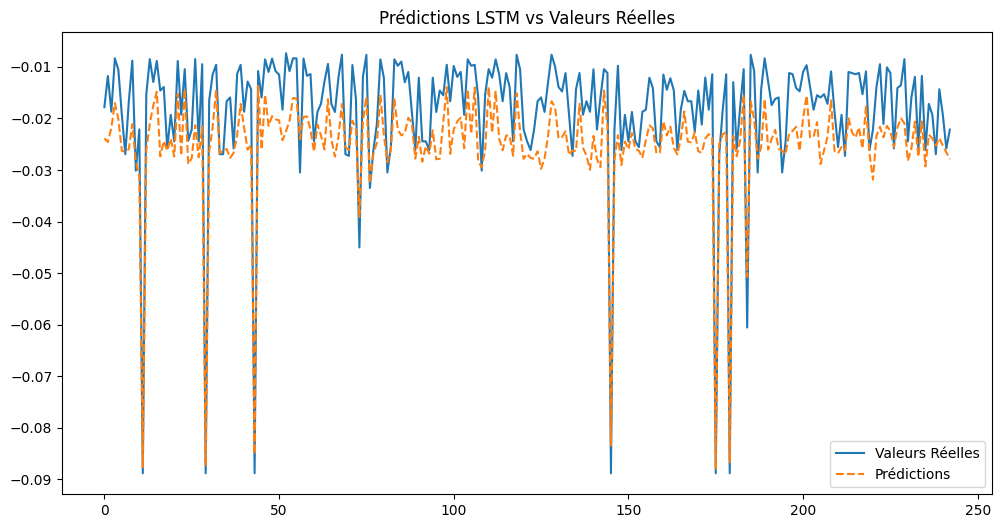

```python
rmse, r2_LSTM = evaluate_model(y_test, y_pred, scaler_target)
```

## Hybrid model CNN-LSTM with wavelet denoising

Cette fonction applique un débruitage de données avec la méthode wavelet :

1. Décompose les données en coefficients wavelet à l'aide de `wavedec`.
2. Calcule un seuil adaptatif basé sur l'estimation de bruit des coefficients.
3. Applique un seuillage doux aux coefficients de détail pour réduire le bruit.
4. Reconstruit les données débruitées avec `waverec`.
5. Gère les erreurs potentielles et retourne les données d'origine en cas de problème.

```python
def wavelet_denoising(data, wavelet='db4', level=2):
    # Débruitage wavelet avec gestion des erreurs
    try:
        coeffs = pywt.wavedec(data, wavelet, level=level)
        # Seuillage doux des coefficients
        sigma = (1/0.6745) * np.median(np.abs(coeffs[-1]))
        for i in range(1, len(coeffs)):
            coeffs[i] = pywt.threshold(coeffs[i], value=sigma, mode='soft')
        denoised_data = pywt.waverec(coeffs, wavelet)
        return denoised_data[:len(data)]
    except Exception as e:
        print(f"Erreur lors du débruitage wavelet : {e}")
        return data
```

1. Cette fonction crée des séquences glissantes pour des séries temporelles.
2. Divise les features en segments de longueur `window_size`.
3. Associe chaque segment à une valeur cible située juste après la fenêtre.
4. Retourne deux tableaux NumPy : les séquences (`X`) et leurs cibles (`y`).

```python
def create_sequences(features, target, window_size=10):
    X, y = [], []
    for i in range(len(features) - window_size):
        X.append(features[i:i+window_size])
        y.append(target[i+window_size])
    return np.array(X), np.array(y)
```

1. Construit un modèle combinant CNN et LSTM pour analyser des séries temporelles.
2. Ajoute une couche `Conv1D` et `MaxPooling1D` pour extraire et réduire les caractéristiques.
3. Intègre deux couches LSTM pour capturer les dépendances temporelles, avec Dropout pour régularisation.
4. Ajoute des couches Dense pour les relations non linéaires et une couche de sortie pour la prédiction.
5. Compile le modèle avec Adam (learning rate 0.001), MSE comme perte, et MAE comme métrique.

```python
def build_advanced_model(input_shape):
    model = Sequential([
        # Couche CNN pour l'extraction de caractéristiques
        Conv1D(filters=64, kernel_size=3, activation='relu', input_shape=input_shape),
        MaxPooling1D(pool_size=2),

        # Couche LSTM pour capturer les dépendances temporelles
        LSTM(100, activation='tanh', return_sequences=True),
        Dropout(0.3),

        LSTM(50, activation='tanh'),
        Dropout(0.2),

        # Couches denses pour l'apprentissage non linéaire
        Dense(64, activation='relu'),
        Dropout(0.2),
        Dense(32, activation='relu'),

        # Couche de sortie
        Dense(1)
    ])

    # Configuration de l'optimiseur avec un taux d'apprentissage adaptatif
    optimizer = tf.keras.optimizers.Adam(learning_rate=0.001)
    model.compile(optimizer=optimizer, loss='mse', metrics=['mae'])

    return model
```

1. Entraîne et évalue un modèle avancé sur des séries temporelles.
2. Configure EarlyStopping et ReduceLROnPlateau pour régularisation et ajustement du taux d'apprentissage.
3. Construit et entraîne le modèle avec validation croisée.
4. Prédit les valeurs sur le test, calcule RMSE et R².
5. Visualise les prédictions vs valeurs réelles et affiche les résultats.
6. Retourne RMSE, R² et le modèle entraîné.

```python
def train_and_evaluate_model(X_train, y_train, X_test, y_test, model_name='Advanced Model'):
    # Création des callbacks
    early_stopping = EarlyStopping(
        monitor='val_loss',
        patience=15,
        restore_best_weights=True
    )

    reduce_lr = ReduceLROnPlateau(
        monitor='val_loss',
        factor=0.2,
        patience=5,
        min_lr=0.00001
    )

    # Construction et entraînement du modèle
    model = build_advanced_model(X_train.shape[1:])

    history = model.fit(
        X_train, y_train,
        epochs=100,
        batch_size=32,
        validation_split=0.2,
        callbacks=[early_stopping, reduce_lr],
        verbose=1
    )

    # Prédictions
    y_pred = model.predict(X_test).flatten()

    # Calcul des métriques
    rmse = np.sqrt(mean_squared_error(y_test, y_pred))
    r2 = r2_score(y_test, y_pred)

    # Visualisation
    plt.figure(figsize=(12,6))
    plt.plot(y_test, label='Valeurs Réelles', color='blue')
    plt.plot(y_pred, label='Prédictions', color='red', linestyle='--')
    plt.title(f'Prédictions vs Valeurs Réelles ({model_name})')
    plt.xlabel('Échantillons')
    plt.ylabel('Valeur')
    plt.legend()
    plt.show()

    print(f"Résultats pour {model_name}:")
    print(f"RMSE: {rmse}")
    print(f"R² Score: {r2}")

    return rmse, r2, model
```

Colonnes de features et target

```python
features_columns = [
    'Apple_Price', 'Apple_Vol.',
    'Tesla_Price', 'Tesla_Vol.',
    'Microsoft_Price', 'Microsoft_Vol.'
]
target_column = 'VaR_S&P_500'
```

Débruitage de la target

```python
data[target_column] = wavelet_denoising(data[target_column].values)
```

Normalisation

```python
scaler_features = MinMaxScaler()
scaler_target = MinMaxScaler()
```

Préparation des features et de la target

```python
X = scaler_features.fit_transform(data[features_columns])
y = scaler_target.fit_transform(data[target_column].values.reshape(-1, 1)).flatten()
```

Création des séquences

```python
X_seq, y_seq = create_sequences(X, y, window_size=10)
```

Division des données

```python
X_train, X_test, y_train, y_test = train_test_split(X_seq, y_seq, test_size=0.2, random_state=42)
```

Entraînement et évaluation du modèle

```python
rmse, r2_CNN_LSTM, model = train_and_evaluate_model(X_train, y_train, X_test, y_test)
```

[output not shown]

## Transformer

```python
import torch
import torch.nn as nn
import torch.optim as optim
from torch.utils.data import DataLoader, TensorDataset
```

1. Implémente un encodage positionnel pour un modèle Transformer.
2. Calcule une matrice d'encodage positionnel basée sur des sinus et cosinus pour représenter les positions dans une séquence.
3. Stocke la matrice d'encodage (pe) en tant que tenseur non paramétrique avec `register_buffer`.
4. Ajoute l'encodage positionnel aux embeddings d'entrée dans la méthode `forward`.

```python
class PositionalEncoding(nn.Module):
    def __init__(self, d_model, max_len=100):
        super(PositionalEncoding, self).__init__()
        position = torch.arange(max_len).unsqueeze(1).float()
        div_term = torch.exp(torch.arange(0, d_model, 2).float() * (-np.log(10000.0) / d_model))
        pe = torch.zeros(max_len, d_model)
        pe[:, 0::2] = torch.sin(position * div_term)
        pe[:, 1::2] = torch.cos(position * div_term)
        self.register_buffer('pe', pe)

    def forward(self, x):
        return x + self.pe[:x.size(1), :]
```

```python
class AdvancedTransformerModel(nn.Module):
    def __init__(self, input_dim, seq_length,
                 d_model=64, nhead=4, num_layers=2,
                 dim_feedforward=128, dropout=0.1):
        super(AdvancedTransformerModel, self).__init__()

        # Input embedding with more robust normalization
        self.input_layer = nn.Sequential(
            nn.Linear(input_dim, d_model),
            nn.LayerNorm(d_model),
            nn.GELU()  # Using GELU instead of ReLU for potentially better performance
        )

        # Positional encoding
        self.positional_encoding = PositionalEncoding(d_model)

        # Transformer encoder layers with modifications
        encoder_layer = nn.TransformerEncoderLayer(
            d_model=d_model,
            nhead=nhead,
            dim_feedforward=dim_feedforward,
            dropout=dropout,
            activation='gelu'  # Changed to GELU
        )
        self.transformer_encoder = nn.TransformerEncoder(
            encoder_layer,
            num_layers=num_layers
        )

        # Output layers with residual connection
        self.output_layers = nn.Sequential(
            nn.Linear(d_model, 64),
            nn.BatchNorm1d(64),
            nn.GELU(),
            nn.Dropout(dropout),
            nn.Linear(64, 32),
            nn.GELU(),
            nn.Linear(32, 1)
        )

    def forward(self, x):
        # x shape: (batch_size, seq_length, input_dim)
        x = self.input_layer(x)  # Embed input
        x = self.positional_encoding(x)  # Add positional encoding

        # Transformer encoder
        x = self.transformer_encoder(x)

        # Take the last time step
        x = x[:, -1, :]

        # Output layers
        return self.output_layers(x)
```

1. Normalise les cibles pour améliorer la stabilité de l'entraînement.
2. Prépare les datasets et dataloaders pour l'entraînement et la validation.
3. Initialise le modèle Transformer avancé et le transfère sur GPU si disponible.
4. Configure l'optimiseur AdamW avec une décroissance de poids et un programmeur de taux d'apprentissage (cosine annealing).
5. Utilise la perte Huber (SmoothL1) pour une régression robuste.
6. Implémente une boucle d'entraînement avec validation et Early Stopping pour éviter le surapprentissage.
7. Sauvegarde le meilleur modèle selon la perte de validation.
8. Charge le meilleur modèle pour l'évaluation finale.
9. Inverse la normalisation des prédictions pour calculer RMSE et R².
10. Visualise les prédictions finales comparées aux valeurs réelles.
11. Retourne RMSE, R², et le modèle entraîné.

```python
def train_and_evaluate_transformer(X_train, y_train, X_test, y_test, epochs=150):
    # Normalize targets to improve training stability
    target_scaler = MinMaxScaler()
    y_train_scaled = target_scaler.fit_transform(y_train.reshape(-1, 1)).flatten()
    y_test_scaled = target_scaler.transform(y_test.reshape(-1, 1)).flatten()

    # Prepare datasets
    train_dataset = TensorDataset(
        torch.tensor(X_train, dtype=torch.float32),
        torch.tensor(y_train_scaled, dtype=torch.float32)
    )
    test_dataset = TensorDataset(
        torch.tensor(X_test, dtype=torch.float32),
        torch.tensor(y_test_scaled, dtype=torch.float32)
    )

    train_loader = DataLoader(train_dataset, batch_size=32, shuffle=True)
    test_loader = DataLoader(test_dataset, batch_size=32, shuffle=False)

    # Device configuration
    device = torch.device("cuda" if torch.cuda.is_available() else "cpu")

    # Model initialization
    input_dim = X_train.shape[2]
    model = AdvancedTransformerModel(input_dim=input_dim, seq_length=X_train.shape[1])
    model.to(device)

    # Optimizer with lower learning rate and adaptive optimization
    optimizer = optim.AdamW(model.parameters(), lr=0.0005, weight_decay=1e-4, amsgrad=True)

    # Learning rate scheduler with cosine annealing
    scheduler = optim.lr_scheduler.CosineAnnealingLR(optimizer, T_max=epochs)

    # Huber Loss for more robust regression
    criterion = nn.SmoothL1Loss()

    # Training loop with early stopping
    best_val_loss = float('inf')
    patience = 15
    trigger_times = 0

    # Training and validation
    for epoch in range(epochs):
        model.train()
        train_loss = 0.0

        for X_batch, y_batch in train_loader:
            X_batch, y_batch = X_batch.to(device), y_batch.to(device)

            optimizer.zero_grad()
            predictions = model(X_batch).squeeze()
            loss = criterion(predictions, y_batch)

            loss.backward()
            torch.nn.utils.clip_grad_norm_(model.parameters(), max_norm=1)
            optimizer.step()

            train_loss += loss.item()

        # Validation
        model.eval()
        val_loss = 0.0
        val_preds, val_true = [], []

        with torch.no_grad():
            for X_batch, y_batch in test_loader:
                X_batch, y_batch = X_batch.to(device), y_batch.to(device)
                predictions = model(X_batch).squeeze()
                val_loss += criterion(predictions, y_batch).item()

                val_preds.extend(predictions.cpu().numpy())
                val_true.extend(y_batch.cpu().numpy())

        val_loss /= len(test_loader)
        scheduler.step()

        # Inverse transform predictions and true values
        val_preds_original = target_scaler.inverse_transform(np.array(val_preds).reshape(-1, 1)).flatten()
        val_true_original = target_scaler.inverse_transform(np.array(val_true).reshape(-1, 1)).flatten()

        # Calculate R²
        r2 = r2_score(val_true_original, val_preds_original)

        print(f"Epoch {epoch+1}, Train Loss: {train_loss/len(train_loader):.4f}, "
              f"Val Loss: {val_loss:.4f}")

        # Early stopping
        if val_loss < best_val_loss:
            best_val_loss = val_loss
            trigger_times = 0
            torch.save(model.state_dict(), 'best_transformer_model.pth')
        else:
            trigger_times += 1
            if trigger_times >= patience:
                print("Early stopping!")
                break

    # Load best model
    model.load_state_dict(torch.load('best_transformer_model.pth'))

    # Final evaluation
    model.eval()
    final_preds, final_true = [], []
    with torch.no_grad():
        for X_batch, y_batch in test_loader:
            X_batch, y_batch = X_batch.to(device), y_batch.to(device)
            predictions = model(X_batch).squeeze()
            final_preds.extend(predictions.cpu().numpy())
            final_true.extend(y_batch.cpu().numpy())

    # Inverse transform final predictions and true values
    final_preds_original = target_scaler.inverse_transform(np.array(final_preds).reshape(-1, 1)).flatten()
    final_true_original = target_scaler.inverse_transform(np.array(final_true).reshape(-1, 1)).flatten()

    # Compute metrics
    rmse = np.sqrt(mean_squared_error(final_true_original, final_preds_original))
    r2 = r2_score(final_true_original, final_preds_original)

    # Visualization
    plt.figure(figsize=(12,6))
    plt.plot(final_true_original, label='Valeurs Réelles', color='blue')
    plt.plot(final_preds_original, label='Prédictions', color='red', linestyle='--')
    plt.title('Prédictions du Modèle Transformer')
    plt.xlabel('Échantillons')
    plt.ylabel('Valeur')
    plt.legend()
    plt.show()

    print(f"RMSE Final: {rmse}")
    print(f"R² Final: {r2}")

    return rmse, r2, model
```

1. Cette fonction prépare des données séquentielles pour des modèles basés sur des séries temporelles.
2. Applique une normalisation Min-Max sur les colonnes de features et la cible.
3. Crée des séquences de longueur spécifiée (`sequence_length`) à partir des features.
4. Associe chaque séquence à la valeur cible correspondante (valeur suivante après la séquence).
5. Convertit les séquences et les cibles en tableaux NumPy.
6. Retourne les séquences, les cibles, et les scalers pour les features et la cible.

```python
def prepare_sequential_data(df, features_columns, target_column, sequence_length=10):

    # Feature Scaling
    feature_scaler = MinMaxScaler()
    target_scaler = MinMaxScaler()

    # Scale features
    features_scaled = feature_scaler.fit_transform(df[features_columns])

    # Scale target
    target_scaled = target_scaler.fit_transform(df[[target_column]])

    # Prepare sequences
    X, y = [], []
    for i in range(len(df) - sequence_length):
        # Create sequence of features
        X.append(features_scaled[i:i+sequence_length])
        # Target is the next value after the sequence
        y.append(target_scaled[i+sequence_length][0])

    # Convert to numpy arrays
    X = np.array(X)
    y = np.array(y)

    return X, y, feature_scaler, target_scaler
```

1. Sélection des colonnes de features (prix et volumes pour Apple, Tesla, Microsoft) et de la cible (`VaR_S&P_500`).
2. Préparation des données séquentielles avec normalisation et création de séquences temporelles de longueur 10.
3. Division des données en ensembles d'entraînement (80%) et de test (20%) avec `train_test_split`.
4. Entraînement d'un modèle Transformer avancé avec la fonction `train_and_evaluate_transformer`.
5. Évaluation des performances du modèle avec les métriques RMSE et R², et visualisation des prédictions.

```
Epoch 1, Train Loss: 0.1759, Val Loss: 0.0624
Epoch 2, Train Loss: 0.0378, Val Loss: 0.0647
Epoch 3, Train Loss: 0.0257, Val Loss: 0.0074
Epoch 4, Train Loss: 0.0229, Val Loss: 0.0158
Epoch 5, Train Loss: 0.0220, Val Loss: 0.0095
Epoch 6, Train Loss: 0.0196, Val Loss: 0.0095
Epoch 7, Train Loss: 0.0156, Val Loss: 0.0085
Epoch 8, Train Loss: 0.0175, Val Loss: 0.0062
Epoch 9, Train Loss: 0.0137, Val Loss: 0.0079
Epoch 10, Train Loss: 0.0128, Val Loss: 0.0080
Epoch 11, Train Loss: 0.0140, Val Loss: 0.0106
Epoch 12, Train Loss: 0.0127, Val Loss: 0.0074
Epoch 13, Train Loss: 0.0138, Val Loss: 0.0070
Epoch 14, Train Loss: 0.0112, Val Loss: 0.0079
Epoch 15, Train Loss: 0.0106, Val Loss: 0.0085
Epoch 16, Train Loss: 0.0156, Val Loss: 0.0089
Epoch 17, Train Loss: 0.0111, Val Loss: 0.0100
Epoch 18, Train Loss: 0.0110, Val Loss: 0.0082
Epoch 19, Train Loss: 0.0101, Val Loss: 0.0068
Epoch 20, Train Loss: 0.0084, Val Loss: 0.0071
Epoch 21, Train Loss: 0.0094, Val Loss: 0.0067
Epoch 22, Train Loss: 0.0076, Val Loss: 0.0061
Epoch 23, Train Loss: 0.0084, Val Loss: 0.0071
Epoch 24, Train Loss: 0.0079, Val Loss: 0.0072
Epoch 25, Train Loss: 0.0069, Val Loss: 0.0067
Epoch 26, Train Loss: 0.0071, Val Loss: 0.0075
Epoch 27, Train Loss: 0.0073, Val Loss: 0.0068
Epoch 28, Train Loss: 0.0075, Val Loss: 0.0075
Epoch 29, Train Loss: 0.0109, Val Loss: 0.0069
Epoch 30, Train Loss: 0.0066, Val Loss: 0.0071
Epoch 31, Train Loss: 0.0071, Val Loss: 0.0085
Epoch 32, Train Loss: 0.0071, Val Loss: 0.0066
Epoch 33, Train Loss: 0.0074, Val Loss: 0.0059
Epoch 34, Train Loss: 0.0079, Val Loss: 0.0070
Epoch 35, Train Loss: 0.0059, Val Loss: 0.0063
Epoch 36, Train Loss: 0.0069, Val Loss: 0.0096
Epoch 37, Train Loss: 0.0067, Val Loss: 0.0062
Epoch 38, Train Loss: 0.0055, Val Loss: 0.0060
Epoch 39, Train Loss: 0.0061, Val Loss: 0.0093
Epoch 40, Train Loss: 0.0056, Val Loss: 0.0060
```

[output cut: 78 more lines]

```
Epoch 119, Train Loss: 0.0026, Val Loss: 0.0042
Epoch 120, Train Loss: 0.0030, Val Loss: 0.0039
Epoch 121, Train Loss: 0.0030, Val Loss: 0.0044
Epoch 122, Train Loss: 0.0028, Val Loss: 0.0040
Epoch 123, Train Loss: 0.0026, Val Loss: 0.0042
Epoch 124, Train Loss: 0.0031, Val Loss: 0.0041
Epoch 125, Train Loss: 0.0028, Val Loss: 0.0039
Epoch 126, Train Loss: 0.0031, Val Loss: 0.0042
Epoch 127, Train Loss: 0.0027, Val Loss: 0.0043
Epoch 128, Train Loss: 0.0028, Val Loss: 0.0054
Epoch 129, Train Loss: 0.0025, Val Loss: 0.0044
Epoch 130, Train Loss: 0.0025, Val Loss: 0.0042
Epoch 131, Train Loss: 0.0042, Val Loss: 0.0043
Epoch 132, Train Loss: 0.0028, Val Loss: 0.0038
Early stopping!
```

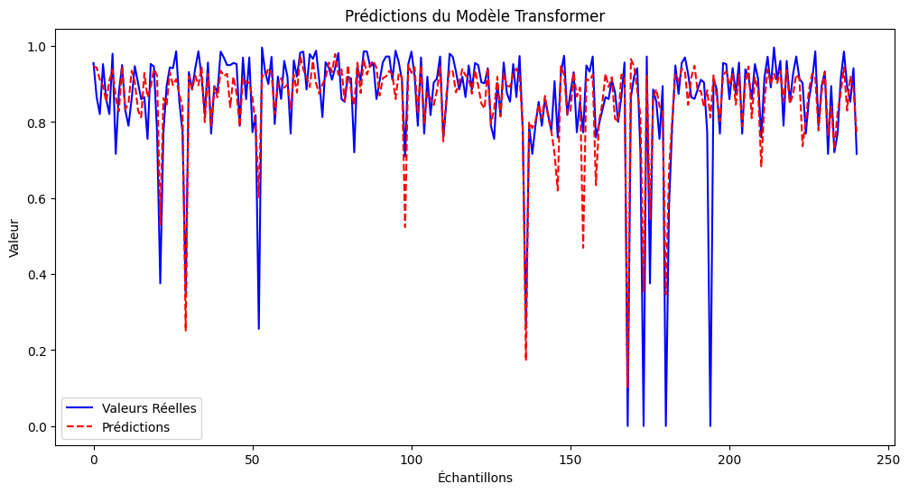

```
RMSE Final: 0.0886964276432991
R² Final: 0.6823121905326843
```

```python
features_columns = ['Apple_Price', 'Apple_Vol.', 'Tesla_Price', 'Tesla_Vol.', 'Microsoft_Price', 'Microsoft_Vol.']
target_column = 'VaR_S&P_500'

# Prepare sequential data
X, y, feature_scaler, target_scaler = prepare_sequential_data(df, features_columns, target_column, sequence_length=10)

# Split the data
from sklearn.model_selection import train_test_split
X_train, X_test, y_train, y_test = train_test_split(X, y, test_size=0.2, random_state=42)

# Train the model
rmse, r2_tr, model = train_and_evaluate_transformer(X_train, y_train, X_test, y_test)
```

## Comparison between the 3 models

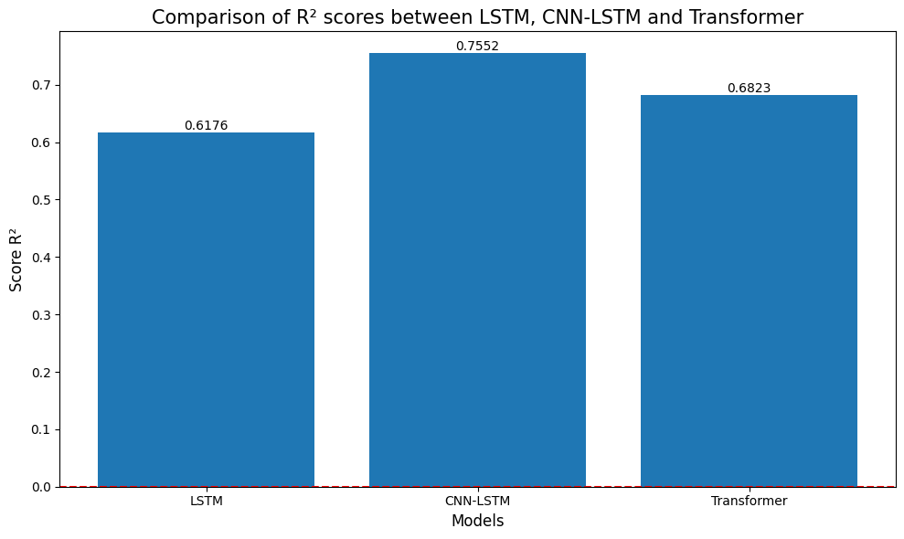

```python
modeles = ['LSTM', 'CNN-LSTM', 'Transformer']
r2_scores = [r2_LSTM, r2_CNN_LSTM, r2_tr]  # Utilisez vos valeurs réelles de R²

plt.figure(figsize=(10, 6))
bars = plt.bar(modeles, r2_scores)
plt.title('Comparison of R² scores between LSTM, CNN-LSTM and Transformer', fontsize=15)
plt.ylabel('Score R²', fontsize=12)
plt.xlabel('Models', fontsize=12)

# Ajout des valeurs sur chaque barre
for bar in bars:
    height = bar.get_height()
    plt.text(bar.get_x() + bar.get_width()/2., height,
             f'{height:.4f}',
             ha='center', va='bottom', fontsize=10)

# Ajout d'une ligne à y=0 pour référence
plt.axhline(y=0, color='r', linestyle='--')

plt.tight_layout()
plt.show()
```